# Example template MASDER

Cody Leporini

2022-06-15

# Hello welcome to the template page!

This is where we will work on making a template and trying some new ideas with the MASDER project. If there are any ideas let me know. The Github link is [here](https://github.com/SDSattitudes/Internal-Notes)

## Questions for MASDER

- What do all the variables link to? (GBeliefs, Attain_1 and so on)
- When we are looking at the variables what are the best things we want to show first
- Can we put a space in between the language values
- what research questions do we want to answer
- Where is the code book for the variables
- equity gaps and ethincity

## Here is the start of the project

First lets read in the data so that way we can see what we are working with

```r
head(data,1)
```

```
## # A tibble: 1 x 134
##   Consent   GBeliefs_1 GBeliefs_2 GBeliefs_3 Global_1 Global_2 Global_3 Global_4
##   <chr>     <chr>      <chr>      <chr>      <chr>    <chr>    <chr>    <chr>
## 1 Yes: I a~ Somewhat ~ Somewhat ~ Strongly ~ Poorly   Below A~ Grater ~ Some Co~
## # ... with 126 more variables: Global_5 <chr>, Gutt1 <chr>, Gutt2 <chr>,
## #   Gutt3 <chr>, Gutt4 <chr>, Gutt5 <chr>, Attain_1 <dbl>, Attain_10 <dbl>,
## #   Attain_11 <dbl>, Attain_12 <dbl>, Attain_13 <dbl>, Attain_2 <dbl>,
## #   Attain_3 <dbl>, Attain_4 <dbl>, Attain_5 <dbl>, Attain_6 <dbl>,
## #   Attain_7 <dbl>, Attain_8 <dbl>, Attain_9 <dbl>, CostX_1 <dbl>,
## #   CostX_2 <dbl>, CostX_3 <dbl>, CostX_4 <dbl>, CostX_5 <dbl>, CostX_6 <dbl>,
## #   CostX_7 <dbl>, CostX_8 <dbl>, CostX_9 <dbl>, CostX_10 <dbl>, ...
```

Lets go ahead and filter out some of the data that we want to see. For example I wanted to take a look at peopel who are hispanic in the data set. Then from there I wanted to make sure they all consented to the survey. After that i wanted to count and display the amount of people who spoke each of the different languages.

```r
data %>%
  drop_na() %>%
  filter(str_detect(Hispanic_Latino_Spanish, 'Yes,')) %>%
  filter(str_detect(Consent, 'Yes')) -> rtadata
data %>%
  drop_na(Language) %>%
  count(Language) -> languagedata
data %>%
  select(Gender,Language) -> test
```

# This is taking a look at the languages

Lets take a quick look at the languages that are being spoken

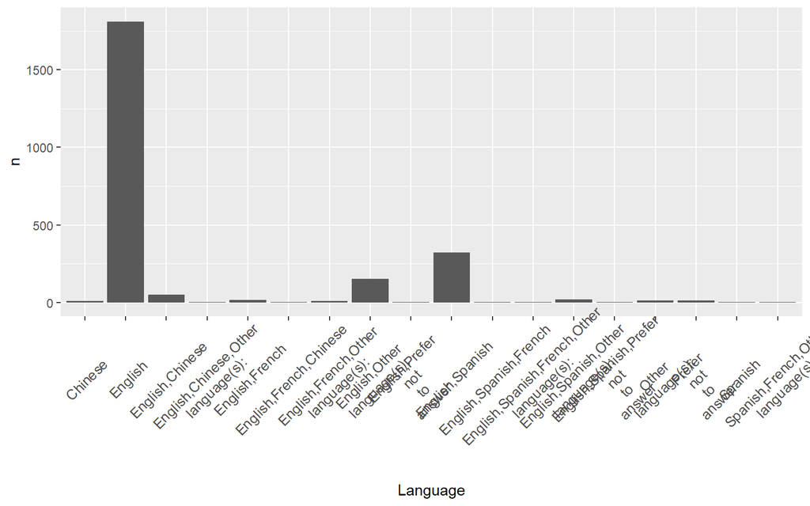

```r
languagedata %>%
  ggplot(aes(x = Language , y = n)) +
  geom_col()+
  scale_x_discrete(labels = function(x) str_wrap(x, width = 1)) +
  theme(axis.text.x = element_text(angle = 45, vjust = .65, size = 10) )
```

[figure not shown]

```r
ggplot(data =  rtadata) +
  aes(y = Attain_1 , x = Language, color = Gender, fill = Gender) +
  geom_col(position = "dodge") +
  labs( x =  "" , y = "" , title = "" , subtitle = "" , caption = "Made by Cody Leporini (MASDER)")+
  facet_wrap(vars(GBeliefs_1) ) +
  scale_x_discrete(labels = function(x) str_wrap(x, width = 1)) +
  theme(axis.text.x = element_text(angle = 45, vjust = .75, size = 12) )
```